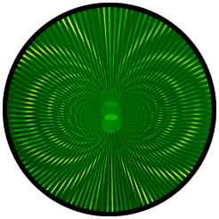

# Ayahuasca, Wellbeing, and Connectedness

## Aldeia Akasha 1H 2025 Results

# Aldeia Akasha: Ayahuasca, Wellbeing, and Connectedness

# Methods

This pilot study administered **three (3) Questionnaires (*Baseline*, *Follow-up*, and *One-Month*)** to participants at **four ceremonial ayahuasca retreats** held at **Aldeia Akasha in Petrópolis, Rio de Janeiro, Brazil** between January and April 2025. Each retreat included three **(3) separate ayahuasca ceremonies** conducted over the course of one week.

Participants completed the *Baseline* questionnaire electronically via Qualtrics at the start of the retreat, **prior to the first ceremony.** Informed consent was obtained through an affirmative response to the consent item included at the beginning of the first questionnaire. Due to its small scale and programmatic nature, the study did not undergo formal IRB review.

The *Baseline* questionnaire collected **demographic data** (age, gender, highest education level, country of origin and residence, primary language, religious affiliation, and prior spiritual or healing practices), **previous ayahuasca experience**, and participants’ **primary intention** for attending the ceremony. To accommodate an **internationally diverse audience**, the education Question included examples from various systems (e.g., *Ensino Fundamental*, *Lycée*, *Grundschule*), and Questionnaires were offered in both **English and Portuguese**.

Participants also completed a section on **recent wellbeing over the past two weeks** (e.g., calmness, irritability, anxiety, depressive symptoms, and life satisfaction) in both the *Baseline* and *One-Month* Questionnaires. A section measuring **nature and social connectedness** appeared in all three Questionnaires: *Baseline*, *Follow-up*, and *One-Month*.

All items used 5-point Likert scales (e.g., from “Strongly disagree” to “Strongly agree” or “Not at all important” to “Extremely important”). Within each section, items were presented in randomized order. Upon completing the *Baseline* questionnaire, participants were assigned an anonymous Participant ID for longitudinal tracking.

Immediately after the 3-ceremony retreat, participants received the *Follow-up* questionnaire, which captured immediate reflections. It repeated the *Baseline* measures of nature and social connectedness and included additional items on **emotional and cognitive effects** (e.g., feelings of peace, connectedness, emotional balance, and insights about personal challenges). Participants also rated the **importance of ceremonial elements**, including the presence of shamans, music, group rituals, and physical setting, on a 5-point Likert scale. Open-ended prompts invited participants to share **notable moments** and the **primary emotion** they experienced post-retreat.

Finally, the *One-Month* questionnaire reassessed recent **wellbeing, nature and social connectedness, and mental health status**, using identical items from earlier Questionnaires to allow for longtitudinal comparisons.

Data analysis and presentation of results were completed using RStudio Version 2025.05.0+496 in June – July 2025.

We gratefully acknowledge the generous support and collaboration of the **Guardians and support staff of Aldeia Akasha ([homepage](https://uniretreats.org/akasha-retreat-center/))**, without whose openness, cooperation, and hospitality this pilot study would not have been possible.

# Results

## Participant Overview

### Table 1: Baseline Participant Characteristics by Retreat

**Table 1** (below) reports demographic characteristics for the **62 participants** who completed the first *(Baseline)* questionnaire.

**Most participants were women (58.1%)** with an **average age of 42 years** (SD = 9.05, range 24–62). **Educational attainment was high**: over half had a bachelor’s or master’s degree (30.6% and 25.8%, respectively). The sample was **internationally diverse, with the largest groups originating from Brazil (30.6%)**, the United Kingdom (17.7%), and United States (16.1%).

|  | Ninawa (N=25) | Colibri Festival (N=14) | Tumã (N=4) | Nixiwaka (N=19) | Total (N=62) |
| --- | --- | --- | --- | --- | --- |
| Gender |  |  |  |  |  |
| Man | 12 (48.0%) | 4 (28.6%) | 2 (50.0%) | 8 (42.1%) | 26 (41.9%) |
| Woman | 13 (52.0%) | 10 (71.4%) | 2 (50.0%) | 11 (57.9%) | 36 (58.1%) |
| Age (years) |  |  |  |  |  |
| Mean (SD) | 40.9 (8.04) | 40.1 (9.67) | 44.5 (12.1) | 44.7 (9.24) | 42.1 (9.05) |
| Median [Min, Max] | 42.0 [24.0, 53.0] | 38.5 [28.0, 62.0] | 41.0 [35.0, 61.0] | 46.0 [26.0, 62.0] | 41.0 [24.0, 62.0] |
| Highest education level |  |  |  |  |  |
| Primary (Elementary) | 0 (0%) | 1 (7.1%) | 0 (0%) | 0 (0%) | 1 (1.6%) |
| Upper Secondary (High) | 3 (12.0%) | 3 (21.4%) | 1 (25.0%) | 3 (15.8%) | 10 (16.1%) |
| Vocational | 4 (16.0%) | 3 (21.4%) | 0 (0%) | 5 (26.3%) | 12 (19.4%) |
| Bachelor's | 11 (44.0%) | 2 (14.3%) | 0 (0%) | 6 (31.6%) | 19 (30.6%) |
| Master's | 4 (16.0%) | 4 (28.6%) | 3 (75.0%) | 5 (26.3%) | 16 (25.8%) |
| Doctoral | 3 (12.0%) | 1 (7.1%) | 0 (0%) | 0 (0%) | 4 (6.5%) |
| Times taken ayahuasca |  |  |  |  |  |
| Never | 6 (24.0%) | 3 (21.4%) | 0 (0%) | 4 (21.1%) | 13 (21.0%) |
| One time | 3 (12.0%) | 3 (21.4%) | 3 (75.0%) | 2 (10.5%) | 11 (17.7%) |
| 2–5 times | 3 (12.0%) | 2 (14.3%) | 0 (0%) | 2 (10.5%) | 7 (11.3%) |
| 6–10 times | 3 (12.0%) | 2 (14.3%) | 0 (0%) | 4 (21.1%) | 9 (14.5%) |
| More than 10 times | 10 (40.0%) | 4 (28.6%) | 1 (25.0%) | 7 (36.8%) | 22 (35.5%) |
| Ceremony intention |  |  |  |  |  |
| Spiritual growth | 11 (44.0%) | 4 (28.6%) | 3 (75.0%) | 13 (68.4%) | 31 (50.0%) |
| Mental health | 6 (24.0%) | 4 (28.6%) | 0 (0%) | 2 (10.5%) | 12 (19.4%) |
| Career | 3 (12.0%) | 4 (28.6%) | 0 (0%) | 2 (10.5%) | 9 (14.5%) |
| Other | 3 (12.0%) | 1 (7.1%) | 0 (0%) | 0 (0%) | 4 (6.5%) |
| Curiosity | 0 (0%) | 1 (7.1%) | 0 (0%) | 2 (10.5%) | 3 (4.8%) |
| Physical health | 2 (8.0%) | 0 (0%) | 1 (25.0%) | 0 (0%) | 3 (4.8%) |
| Country of origin |  |  |  |  |  |
| Brazil | 9 (36.0%) | 6 (42.9%) | 0 (0%) | 4 (21.1%) | 19 (30.6%) |
| United Kingdom | 6 (24.0%) | 0 (0%) | 0 (0%) | 5 (26.3%) | 11 (17.7%) |
| United States | 1 (4.0%) | 2 (14.3%) | 3 (75.0%) | 4 (21.1%) | 10 (16.1%) |
| France | 2 (8.0%) | 1 (7.1%) | 0 (0%) | 0 (0%) | 3 (4.8%) |
| Germany | 0 (0%) | 2 (14.3%) | 0 (0%) | 1 (5.3%) | 3 (4.8%) |
| Sweden | 2 (8.0%) | 0 (0%) | 0 (0%) | 0 (0%) | 2 (3.2%) |
| Switzerland | 2 (8.0%) | 0 (0%) | 0 (0%) | 0 (0%) | 2 (3.2%) |
| Turkey | 0 (0%) | 0 (0%) | 1 (25.0%) | 1 (5.3%) | 2 (3.2%) |
| Argentina | 1 (4.0%) | 0 (0%) | 0 (0%) | 0 (0%) | 1 (1.6%) |
| Australia | 1 (4.0%) | 0 (0%) | 0 (0%) | 0 (0%) | 1 (1.6%) |
| Austria | 0 (0%) | 1 (7.1%) | 0 (0%) | 0 (0%) | 1 (1.6%) |
| Chile | 0 (0%) | 0 (0%) | 0 (0%) | 1 (5.3%) | 1 (1.6%) |
| Iran | 0 (0%) | 0 (0%) | 0 (0%) | 1 (5.3%) | 1 (1.6%) |
| Ireland | 1 (4.0%) | 0 (0%) | 0 (0%) | 0 (0%) | 1 (1.6%) |
| Italy | 0 (0%) | 0 (0%) | 0 (0%) | 1 (5.3%) | 1 (1.6%) |
| Mexico | 0 (0%) | 0 (0%) | 0 (0%) | 1 (5.3%) | 1 (1.6%) |
| Netherlands | 0 (0%) | 1 (7.1%) | 0 (0%) | 0 (0%) | 1 (1.6%) |
| Romania | 0 (0%) | 1 (7.1%) | 0 (0%) | 0 (0%) | 1 (1.6%) |
| Country of residence |  |  |  |  |  |
| Brazil | 12 (48.0%) | 5 (35.7%) | 0 (0%) | 4 (21.1%) | 21 (33.9%) |
| United Kingdom | 7 (28.0%) | 2 (14.3%) | 0 (0%) | 7 (36.8%) | 16 (25.8%) |
| United States | 1 (4.0%) | 3 (21.4%) | 3 (75.0%) | 4 (21.1%) | 11 (17.7%) |
| Germany | 0 (0%) | 2 (14.3%) | 1 (25.0%) | 1 (5.3%) | 4 (6.5%) |
| Chile | 0 (0%) | 0 (0%) | 0 (0%) | 2 (10.5%) | 2 (3.2%) |
| France | 1 (4.0%) | 1 (7.1%) | 0 (0%) | 0 (0%) | 2 (3.2%) |
| Argentina | 1 (4.0%) | 0 (0%) | 0 (0%) | 0 (0%) | 1 (1.6%) |
| Ireland | 1 (4.0%) | 0 (0%) | 0 (0%) | 0 (0%) | 1 (1.6%) |
| Netherlands | 0 (0%) | 1 (7.1%) | 0 (0%) | 0 (0%) | 1 (1.6%) |
| Portugal | 1 (4.0%) | 0 (0%) | 0 (0%) | 0 (0%) | 1 (1.6%) |
| Sweden | 1 (4.0%) | 0 (0%) | 0 (0%) | 0 (0%) | 1 (1.6%) |
| United Arab Emirates | 0 (0%) | 0 (0%) | 0 (0%) | 1 (5.3%) | 1 (1.6%) |

### Table 2: Questionnaire Completion by Retreat

*Displaying only participants with IDs matched to baseline*

**Twenty-four (24) participants completed all three Questionnaires,** out of **62 total participants** who enrolled in the pilot**. Overall retention was thus 39%,** with retention varying by retreat from Tumã at 0% retention to Ninawa at 52% retention. *Follow-up* questionnaire retention averaged 73% overall, ranging from 43% for COLIBRI to 89% for Nixiwaka.

| Retreat | Baseline (n, %) | Follow-up (n, % retention) | 1-Mo (n, % retention) |
| --- | --- | --- | --- |
| Ninawa | 25 | 19 (76%) | 13 (52%) |
| Colibri Festival | 14 | 6 (43%) | 2 (14%) |
| Tumã | 4 | 3 (75%) | 0 (0%) |
| Nixiwaka | 19 | 17 (89%) | 9 (47%) |
| Total | 62 | 45 (73%) | 24 (39%) |

### Who’s Taken Ayahuasca Before, and Why?

#### Chart 1: How Many Times Have Participants Taken Ayahuasca?

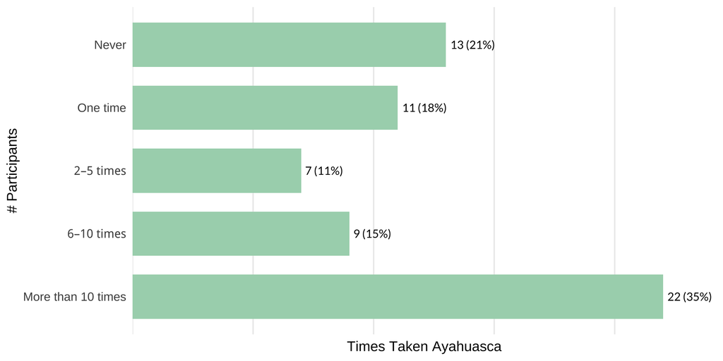

#### Chart 2: Why are Participants Taking Ayahuasca?

**Spiritual growth** was the most common intention across nearly all experience levels. It dominated especially among participants with more ayahuasca experience, making up **56%** of intentions among those who had taken it 6–10 times and **68%** among those with 10+ experiences. **Career-related** intentions appeared fairly evenly across groups, while curiosity and physical health were mentioned only by a few participants. Interestingly, in the “2–5 times” group, **mental health** was the leading intention (57%), suggesting that participants newer to ayahuasca may engage with it initially for psychological reasons before shifting toward more spiritually framed goals. Overall, while intention profiles are broadly similar, experience level seems to shape the relative prominence of certain motivations, especially the increasing focus on spiritual growth with repeated use.

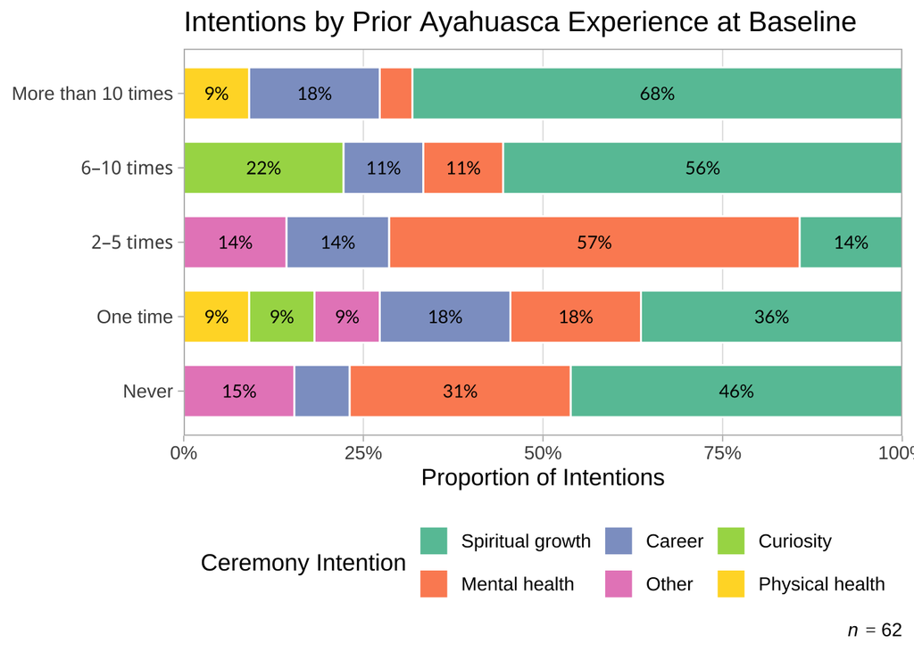

```
##
##  Fisher's Exact Test for Count Data
##
## data:  tbl
## p-value = 0.04131
## alternative hypothesis: true odds ratio is not equal to 1
## 95 percent confidence interval:
##   1.041154 10.670236
## sample estimates:
## odds ratio
##   3.238752
```

Indeed, participants with high ayahuasca experience (6 previous ceremonies or more, *n* = 31) had significantly greater odds of reporting spiritual-growth intent compared to those with low experience. A Fisher’s Exact Test indicated that the odds of choosing spiritual intent were **3.2 times higher** in the high-experience group than in the low-experience group (odds ratio = 3.24, 95% CI: 1.04 to 10.67, *p* = 0.041*). Because the confidence interval does not include 1, this suggests a statistically significant association between past ayahuasca use and reported spiritual motivation. While the wide confidence interval reflects the limited data in this pilot, these results provide evidence of an association worth further study.

## Nature & Social Connectedness

### Table 3: How Participants’ Nature and Social Connectedness Evolved After Retreat

Mean response on each **Nature and Social Connectedness** section at three timepoints, where 5 = Strongly Agree and 1 = Strongly Disagree.

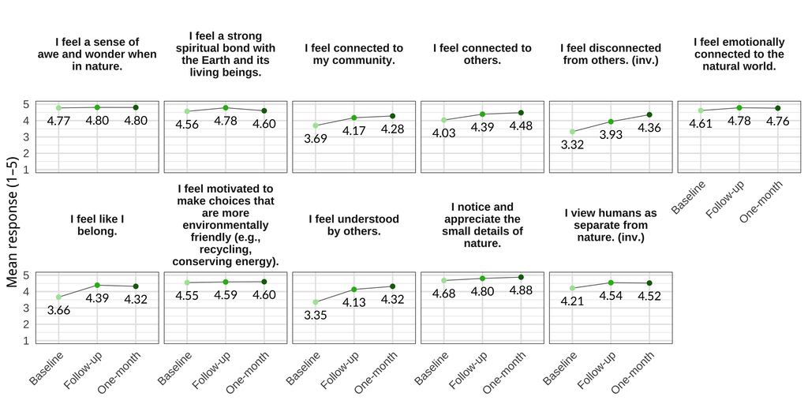

### Table 4: Mixed Models on Nature and Social Connectedness

Table 4 summarizes paired comparisons between *Baseline* and both subsequent Questionnaires (*Follow-up* and *One-month*) across 11 Questions on **Nature and Social connectedness**.

Statistically significant improvements (*p* < .05) were found primarily in items related to social connectedness. One month after their retreats, participants reported large **reductions in feelings of disconnection from others** (**β = -1.04**, *p* < .001***), in addition to increases in their feeling of **being understood by others** (**β = -1.01**, *p* <.001***) and **sense of belonging** (**β = -0.68**, *p* < .01**). Participants also reported moderate increases in their **sense of connection to others** (**β = -0.48**, *p* < .011*) and to their community (**β = -0.60**, *p* < .01**). Many of these effects were already apparent at *Follow-up* and persisted or strengthened by *One-month*.

In contrast, most items measuring **nature connectedness**, such as feelings of awe and wonder in nature or spiritual bonds with the Earth, showed no significant changes. A notable exception was the item “*I notice and appreciate the small details of nature*,” (**β = -0.28**, *p* < .01**)) which showed a slight but significant improvement, indicating that participants experienced enhanced attentiveness to subtle aspects of the natural world one month after the retreat.

Overall, these results suggest the retreat mostly had a **broad and substantial impact on social connectedness**, in addition to benefitting an appreciation of the small details of nature.

| Question | Timeline Pair | Estimate | SE | DF | p-value |
| --- | --- | --- | --- | --- | --- |
| I feel a sense of awe and wonder when in nature. | Baseline to Follow-up | -0.02 | 0.10 | 87.7 | 0.828 |
| I feel a sense of awe and wonder when in nature. | Baseline to One-month | -0.03 | 0.13 | 102.2 | 0.784 |
| I feel a strong spiritual bond with the Earth and its living beings. | Baseline to Follow-up | -0.23 | 0.12 | 87.1 | 0.068 |
| I feel a strong spiritual bond with the Earth and its living beings. | Baseline to One-month | -0.06 | 0.15 | 100.6 | 0.714 |
| I feel connected to my community. | Baseline to Follow-up | -0.47 | 0.17 | 83.4 | <.01** |
| I feel connected to my community. | Baseline to One-month | -0.60 | 0.21 | 91.0 | <.01** |
| I feel connected to others. | Baseline to Follow-up | -0.35 | 0.15 | 85.0 | 0.019* |
| I feel connected to others. | Baseline to One-month | -0.48 | 0.18 | 94.9 | 0.011* |
| I feel disconnected from others. (inv.) | Baseline to Follow-up | -0.53 | 0.20 | 84.0 | 0.010* |
| I feel disconnected from others. (inv.) | Baseline to One-month | -1.04 | 0.26 | 92.4 | <.001*** |
| I feel emotionally connected to the natural world. | Baseline to Follow-up | -0.17 | 0.12 | 87.5 | 0.163 |
| I feel emotionally connected to the natural world. | Baseline to One-month | -0.16 | 0.15 | 101.3 | 0.281 |
| I feel like I belong. | Baseline to Follow-up | -0.71 | 0.18 | 86.1 | <.001*** |
| I feel like I belong. | Baseline to One-month | -0.68 | 0.22 | 97.5 | <.01** |
| I feel motivated to make choices that are more environmentally friendly (e.g., recycling, conserving energy). | Baseline to Follow-up | -0.04 | 0.09 | 82.2 | 0.652 |
| I feel motivated to make choices that are more environmentally friendly (e.g., recycling, conserving energy). | Baseline to One-month | -0.11 | 0.12 | 88.5 | 0.343 |
| I feel understood by others. | Baseline to Follow-up | -0.79 | 0.17 | 85.9 | <.001*** |
| I feel understood by others. | Baseline to One-month | -1.01 | 0.22 | 97.1 | <.001*** |
| I notice and appreciate the small details of nature. | Baseline to Follow-up | -0.15 | 0.08 | 82.7 | 0.052 |
| I notice and appreciate the small details of nature. | Baseline to One-month | -0.28 | 0.10 | 89.6 | <.01** |
| I view humans as separate from nature. (inv.) | Baseline to Follow-up | -0.22 | 0.17 | 82.6 | 0.179 |
| I view humans as separate from nature. (inv.) | Baseline to One-month | -0.31 | 0.21 | 89.1 | 0.147 |

Note:  
Significance codes: * p < .05; ** p < .01; *** p < .001

## Recent Wellbeing

### Table 5: How Participants’ Recent Wellbeing Evolved After Retreat

Mean response on each **Recent Wellbeing** section at two timepoints, where 5 = Strongly Agree and 1 = Strongly Disagree. Note that recent wellbeing Questions were not asked at *Follow-up*, only at *Baseline* and *One-month*.

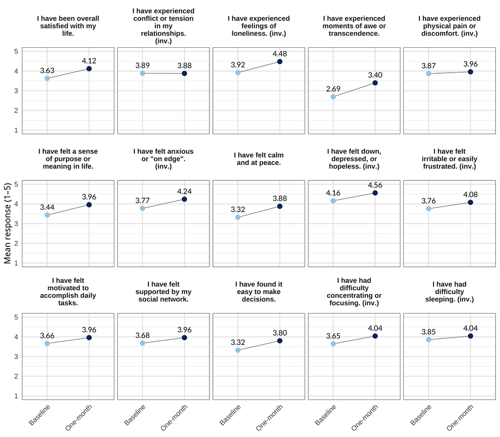

### Table 6: Mixed Models on Recent Wellbeing

Participants showed **broad and statistically significant** improvements across emotional, existential, and cognitive domains from baseline to one month following the retreat. As shown in *Table 6*, participants reported **reduced symptoms of psychological distress**, including **loneliness** (β = -0.59, p < .001***) and anxiety (β = -0.49, p < .01**), depression (β = -0.44, p < .01**), difficulty concentrating (β = -0.41, p < .01**), and irritability (β = -0.37, p = .032*). These estimates (β) represent decreases of roughly one-third to over half a scale point on the 5-point Likert scale used, corresponding to **moderate to large effect sizes.**

Positive shifts were also observed in life satisfaction (β = -0.49, p = .013*), calmness and peace (β = -0.61, p < .01**), and ease making decisions (β = -0.50, p = .023*). Participants also reported **more frequent experiences of awe or transcendence** (β = -0.80, p < .001***), a change close to a full scale point, suggesting a particularly strong impact in this domain.

Other outcomes including sense of purpose, physical discomfort, sleep quality, and perceived social support trended in a positive direction, but did not reach statistical significance. No change was observed in relationship conflict. Taken together, these results suggest a broad and meaningful **improvement in psychological wellbeing, emotional regulation, and existential engagement** one month after the retreat.

| Question | Timeline Pair | Estimate | SE | DF | p-value |
| --- | --- | --- | --- | --- | --- |
| I have been overall satisfied with my life. | Baseline to One-month | -0.49 | 0.19 | 42.3 | 0.013* |
| I have experienced conflict or tension in my relationships. (inv.) | Baseline to One-month | -0.01 | 0.13 | 44.3 | 0.967 |
| I have experienced feelings of loneliness. (inv.) | Baseline to One-month | -0.59 | 0.15 | 36.1 | <.001*** |
| I have experienced moments of awe or transcendence. | Baseline to One-month | -0.80 | 0.20 | 35.4 | <.001*** |
| I have experienced physical pain or discomfort. (inv.) | Baseline to One-month | -0.15 | 0.21 | 43.5 | 0.492 |
| I have felt a sense of purpose or meaning in life. | Baseline to One-month | -0.48 | 0.24 | 39.5 | 0.053 |
| I have felt anxious or “on edge”. (inv.) | Baseline to One-month | -0.49 | 0.15 | 37.2 | <.01** |
| I have felt calm and at peace. | Baseline to One-month | -0.61 | 0.20 | 47.7 | <.01** |
| I have felt down, depressed, or hopeless. (inv.) | Baseline to One-month | -0.44 | 0.14 | 43.1 | <.01** |
| I have felt irritable or easily frustrated. (inv.) | Baseline to One-month | -0.37 | 0.16 | 40.2 | 0.032* |
| I have felt motivated to accomplish daily tasks. | Baseline to One-month | -0.40 | 0.19 | 39.7 | 0.040* |
| I have felt supported by my social network. | Baseline to One-month | -0.28 | 0.24 | 47.1 | 0.248 |
| I have found it easy to make decisions. | Baseline to One-month | -0.50 | 0.21 | 39.7 | 0.023* |
| I have had difficulty concentrating or focusing. (inv.) | Baseline to One-month | -0.41 | 0.13 | 31.0 | <.01** |
| I have had difficulty sleeping. (inv.) | Baseline to One-month | -0.24 | 0.14 | 30.7 | 0.112 |

Note:  
Significance codes: * p < .05; ** p < .01; *** p < .001

## Ceremonial Setting

### Which aspects of the ceremony were most important to participants?

According to *Chart 3*, participants rated **Music highest** (more than 90% rated it “Extremely important”), followed by **Physical environment** and **Shaman presence** (around 88–95% “Strongly Agree/Agree”). **Rituals & prayers** and **Group setting** also skew positively.

#### Chart 3: Distribution of Responses for Ceremonial Setting Section

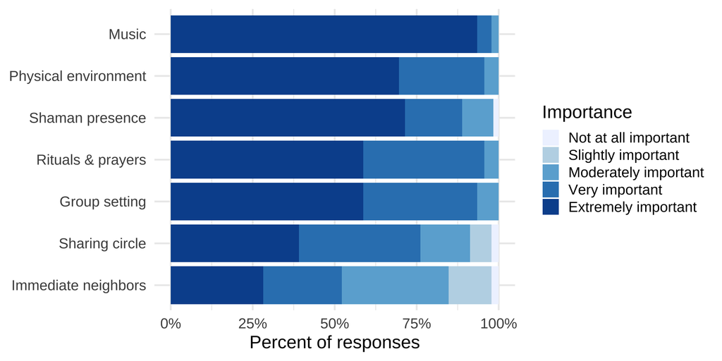

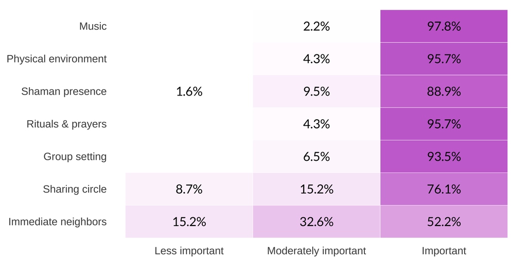

```
## # A tibble: 7 × 2
##   Aspect               mean_rating
##   <chr>                      <dbl>
## 1 Music                       4.91
## 2 Physical environment        4.65
## 3 Shaman presence             4.57
## 4 Rituals & prayers           4.54
## 5 Group setting               4.52
## 6 Sharing circle              4.04
## 7 Immediate neighbors         3.63
```